# Using Sankey diagrams

BI Team, Sheffield City Council

18 July, 2022

[*View source*](https://github.com/scc-pi/sankeysheff/blob/main/sankey.Rmd)

# 1 Introduction

> Sankey Diagrams are directed, weighted graphs.

> Sankey Diagrams are particularly appropriate for representing flow through a system in that it gives an immediate visualisation of the weight of the flows and thus enables priority areas to be identified and tackled.

The purpose of these notes is to explore how to use Sankey diagrams via R. In particular, for the Early Intervention & Prevention programme (EIP).

We have had some initial success producing Sankey diagrams for Pass 1 of the Children’s Early Help (CEH) project, which is part of the EIP programme. To build on this success we need to better understand:

1. Network analysis, of which Sankeys are a part.
2. JavaScript, and in particular the D3 library, for dynamic, interactive data visualisations in web browsers.

## 1.1 Resources

The reading and examples around this subject were frustratingly piecemeal until we came across the new [Handbook of Graphs and Networks in People Analytics](https://ona-book.org/) (2022, Keith McNulty). The Foreword, Introduction and Chapter 1 provide motivation and outline practical applications of graphs and networks. Chapters 2, 3, 4, and 11 are more technical and provide the basis for what we need for the CEH project.

The example followed in the CEH project for Pass 1 (before we found the handbook) was [Most basic Sankey Diagram – the R Graph Gallery (r-graph-gallery.com)](https://r-graph-gallery.com/321-introduction-to-interactive-sankey-diagram-2.html). The [R Gallery Book](https://bookdown.org/content/b298e479-b1ab-49fa-b83d-a57c2b034d49/flow.html#sankey-diagram) would have been better to work from.

Other resources used or identified include:

- [Introduction to Network Analysis with R](https://www.jessesadler.com/post/network-analysis-with-r/) (2017, Jesse Sadler).
- Chapter on [Network analysis with R](https://thomasdegraaff.nl/ResearchTools/network-analysis-with-r.html) from [Research Tools for Social Scientists](https://thomasdegraaff.nl/ResearchTools/index.html) (2017, Thomas de Graaff).
- [Network Analysis and Visualization with R and igraph](https://kateto.net/netscix2016.html) (2016, Katherine Ognyanova).
- [Static and dynamic network visualization with R](https://kateto.net/network-visualization) (2021, Katherine Ognyanova).
- [Network Analysis and Visualization in R: Quick Start Guide](https://www.amazon.co.uk/dp/B077RHSB3Y/ref=dp-kindle-redirect?_encoding=UTF8&btkr=1) (2017, Alboukadel Kassambara).
- [A User’s Guide to Network Analysis in R](https://link.springer.com/book/10.1007/978-3-319-23883-8) (2015, Douglas Luke).

## 1.2 Network analysis

*Vertices* and *edges* seem to be the key terms used in network analysis books. Probably not as intuitive as the terms *nodes* and *links* used in some R packages. *Points* and *lines* would probably not differentiate it enough from a regular x and y axis graph. *Junctions* and *roads* too metaphorical? The *amount of traffic*, *weight*, *size of flow*, *value*, *edge attribute*, all relate to how much is passing from one vertex to another.

In addition to other types of network visualisation, such as chord or weighted arc diagrams, network analysis is useful where connections rather than transactions are the priority.

> Graph databases store data so that finding relationships is the primary priority. This contrasts with traditional databases where finding transactions is the primary priority.

## 1.3 networkD3 package

These notes are going to focus on using the `networkD3` R package: christophergandrud.github.io/networkD3/.

Other Sankey and Alluvial specific packages were considered. However, `networkD3` seemed the best bet in terms of package maintenance and examples. Plus, familiarity with the package could help us produce other types of network diagrams. Consideration of other packages was not especially thorough.

> The networkD3 package offers useful, convenient ways for non-Javascript programmers to make use of many of the great capabilities of the D3 visualisation library. However, the package’s customization potential is limited. For those who can program in D3, the scope exists to create amazing interactive graph visualisations, with limitless customization potential.

We don’t need the Sankey to be dynamic and interactive for CEH. Certainly not initially for the high level group visualisations. However, Sankey’s quickly become unwieldy with too much information, which is where the interaction, the ability for the reader to explore the diagram, is useful. Additionaly, the D3 options for Sankey are simpler to use than to build a static alternative. In short, some JavaScript looks unavoidable. Reassuringly, Hadley Wickham tweeted recently that he expected JavaScript to be tied to the future of R visualisations, so it’s a good skill to invest in.

James Ford has asked about the possibility of a *Sankey Pivot* - a Sankey where different aspects can be selected. Maybe something like this, observablehq.com/@d3/sankey, but with, for example, being able to select of types of Early Help, rather than link colour. Including the Sankey in a flexdashboard might be the easiest way to accomplish this and avoid too much JavaScript.

# 2 Handbook Sankey example

Sankey example from the Handbook in [3.1.5 Interactive graph visualization using ‘networkD3’](https://ona-book.org/viz-graphs.html#interactive-graph-visualization-using-networkd3).

```r
# get data
eu_referendum <- read.csv(
  "https://ona-book.org/data/eu_referendum.csv"
)

# aggregate by region
results <- eu_referendum |>
  dplyr::group_by(Region) |>
  dplyr::summarise(Remain = sum(Remain), Leave = sum(Leave)) |>
  tidyr::pivot_longer(-Region, names_to = "result",
                      values_to = "votes")

# create unique regions, "Leave" and "Remain" for nodes dataframe
regions <- unique(results$Region)
nodes <- data.frame(node = c(0:13),
                    name = c(regions, "Leave", "Remain"))

# create edges/links dataframe
results <- results |>
  dplyr::inner_join(nodes, by = c("Region" = "name")) |>
  dplyr::inner_join(nodes, by = c("result" = "name"))

links <- results[ , c("node.x", "node.y", "votes")]
colnames(links) <- c("source", "target", "value")

# visualize using sankeyNetwork
networkD3::sankeyNetwork(
  Links = links, Nodes = nodes, Source = 'source', Target = 'target',
  Value = 'value', NodeID = 'name', units = 'votes', fontSize = 12
)
```

```
## Links is a tbl_df. Converting to a plain data frame.
```

[interactive chart not shown]

# 3 Another Sankey example

A good outline of the Sankey process using the `networkD3` package - [RPubs - Introduction to Creating Sankey diagrams for Educational Research In R](https://rpubs.com/droach/CPP526-codethrough).

*TODO?*

# 4 Dummy CEH data

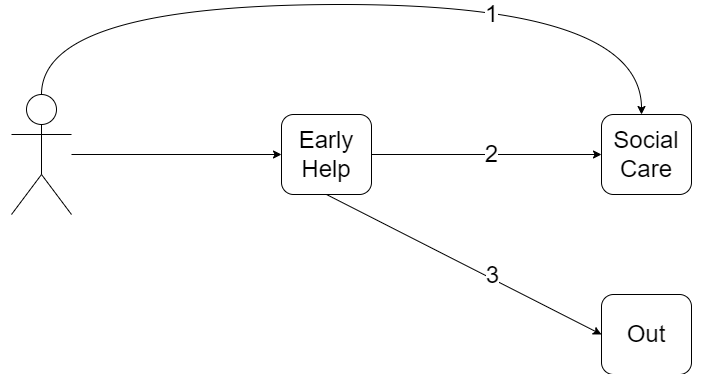

We’ll use the groupings we have of children that receive either Social Care interventions (group 1), Early Help engagements (group 3), or both (group 2).

> Create a data frame of nodes

```r
# Nodes of our groups with some sample data
ceh_groups <- tribble(
    ~GROUP,      ~CHILDREN,
    "1 SC",     4000,
    "2 EH SC",  4000,
    "3 EH",     22000
  )

# Starting node i.e. our cohort of children
ceh_children <- ceh_groups %>%
  count(wt = CHILDREN, name = "CHILDREN", GROUP = "Children")

# Early Help node
ceh_early_help <- ceh_groups %>%
  filter(GROUP != "1 SC") %>%
  count(wt = CHILDREN, name = "CHILDREN", GROUP = "Early Help")

# Combine the nodes in a single data frame
ceh_nodes <- bind_rows(ceh_children, ceh_early_help, ceh_groups)

# Tidy as we go
rm(ceh_groups, ceh_children, ceh_early_help)

# Display nodes table
ceh_nodes %>%
  display_tbl() %>%
  fmt_number(columns = CHILDREN, decimals = 0, use_seps = TRUE)
```

| GROUP | CHILDREN |
| --- | --- |
| Children | 30,000 |
| Early Help | 26,000 |
| 1 SC | 4,000 |
| 2 EH SC | 4,000 |
| 3 EH | 22,000 |

> Create a data frame of connections

```r
# Connections data frame
ceh_connections <- tribble(
    ~from,        ~to,
    "Children",   "1 SC",
    "Children",   "Early Help",
    "Early Help", "2 EH SC",
    "Early Help", "3 EH"
  ) %>%
  left_join(ceh_nodes, by = c("to" = "GROUP")) #add edge attribute

# Display connections table
ceh_connections %>%
  display_tbl() %>%
  fmt_number(columns = CHILDREN, decimals = 0, use_seps = TRUE)
```

| from | to | CHILDREN |
| --- | --- | --- |
| Children | 1 SC | 4,000 |
| Children | Early Help | 26,000 |
| Early Help | 2 EH SC | 4,000 |
| Early Help | 3 EH | 22,000 |

## 4.1 igraph example

Using the [`igraph` R package](https://igraph.org/r/) as suggested by the [`networkD3` documentation](https://christophergandrud.github.io/networkD3/#igraph).

Using `igraph` might be akin to the use of data standards and APIs i.e. a useful agreed common format, for network analysis. Initially it’s use appears an unnecessary complication, but down the line its value may become more apparent.

```r
# Create the igraph object by passing it a data frame containing a symbolic edge
# list in the first 2 columns e.g. from & to.
# Additional columns are considered as edge attributes.
ceh_graph <- graph_from_data_frame(
  ceh_connections,
  vertices = ceh_nodes, #data frame with vertex metadata
  directed = TRUE
)

# Convert to object suitable for networkD3
# One data frame of 'links' and another of 'nodes' returned in a list
ceh_d3 <- igraph_to_networkD3(ceh_graph, what = "both")

# Display links table
ceh_d3$links %>%
  display_tbl %>%
  fmt_number(columns = value, decimals = 0, use_seps = TRUE)
```

| source | target | value |
| --- | --- | --- |
| 0 | 2 | 4,000 |
| 1 | 3 | 4,000 |
| 1 | 4 | 22,000 |
| 0 | 1 | 26,000 |

```r
# Display nodes table
ceh_d3$nodes %>%
  display_tbl()
```

| name |
| --- |
| Children |
| Early Help |
| 1 SC |
| 2 EH SC |
| 3 EH |

```r
# Display D3 Sankey diagram
sankeyNetwork(
  Links = ceh_d3$links,
  Nodes = ceh_d3$nodes,
  Source = "source",
  Target = "target",
  Value = "value",
  NodeID = "name",
  nodeWidth = 40,
  fontSize = 13,
  nodePadding = 20,
  units = "children"
)
```

[interactive chart not shown]

# 5 Current function

```r
# Sankey of different Early Help & Social Care groups
group_sankey <- function(grp_count,
                         sc_int_count = NULL,
                         char_count = NULL){

  # NOTE: Sankey is D3 based, which unlike R has 0 based index

  # Create a frame for a Children's Early Help groups Sankey
  eip_grps_sk_frm <- tribble(
    ~SOURCE,      ~ID_SOURCE, ~TARGET,      ~ID_TARGET,
    "Children",   0,          "1 SC",       1,
    "Children",   0,          "Early Help", 2,
    "Early Help", 2,          "2 EH SC",    3,
    "Early Help", 2,          "3 EH",       4
  )

  # 2nd function argument?
  if (!is.null(sc_int_count)) {
    # Create a frame for a Children's SC interventions Sankey
    sc_int_sk_frm <- tribble(
      ~SOURCE,      ~ID_SOURCE, ~TARGET,      ~ID_TARGET,
      "1 SC",       1,          "CIN",        2,
      "1 SC",       1,          "CPP",        3,
      "1 SC",       1,          "CLA",        4,
      "2 EH SC",    5,          "CIN",        2,
      "2 EH SC",    5,          "CPP",        3,
      "2 EH SC",    5,          "CLA",        4
    )

    # Add to SC interventions to main Sankey frame
    eip_grps_sk_frm <- eip_grps_sk_frm %>%
      mutate(
        ID_TARGET = if_else(ID_TARGET > 1, ID_TARGET + 3, ID_TARGET),
        ID_SOURCE = if_else(ID_SOURCE > 1, ID_SOURCE + 3, ID_SOURCE)
      ) %>%
      bind_rows(sc_int_sk_frm)
  }

  # 3rd function argument?
  if (is.null(char_count)) {
    char_rows <- 0
  } else {

    # Number of different categories in the characteristic
    char_rows <- nrow(char_count)

    # Assume first column has the category names!
    char_count <- rename(char_count, SOURCE = 1)

    # Create a frame for a Children's characteristics Sankey
    char_count_sk_frm <- char_count %>%
      select(SOURCE) %>%
      mutate(
        ID_SOURCE = row_number() - 1,
        TARGET = "Children",
        ID_TARGET = char_rows
      )

    # Add to characteristic categories to main Sankey frame
    eip_grps_sk_frm <- eip_grps_sk_frm %>%
      mutate(
        ID_TARGET = ID_TARGET + char_rows,
        ID_SOURCE = ID_SOURCE + char_rows
      ) %>%
      bind_rows(char_count_sk_frm, .) #put char. rows at the top
  }

  # How many children in total?
  child_count <- grp_count %>%
    count(wt = CHILDREN) %>%
    pluck(1,1)

  # How many child had Early Help in total?
  early_help_child_count <- grp_count %>%
    filter(str_detect(GROUP, "EH")) %>%
    select(-GROUP) %>%
    count(wt = CHILDREN) %>%
    pluck(1,1)

  # Add the values to our Sankey frame
  eip_grps_sk <- eip_grps_sk_frm %>%
    left_join(grp_count, by = c("TARGET" = "GROUP")) %>%
    # 2nd argument?
    {
      if (!is.null(sc_int_count)) {
        left_join(
          .,
          sc_int_count,
          by = c("SOURCE" = "GROUP", "TARGET" = "INTERVENTION_TYPE")
        ) %>%
        mutate(
            CHILDREN = if_else(is.na(CHILDREN.x), CHILDREN.y, CHILDREN.x)
        ) %>%
        select(-CHILDREN.x, -CHILDREN.y)
      } else {
        .
      }
    } %>%
    # 3rd argument?
    {
      if (!is.null(char_count)) {
        left_join(., char_count, by = "SOURCE") %>%
        mutate(
            CHILDREN = if_else(is.na(CHILDREN.x), CHILDREN.y, CHILDREN.x)
        ) %>%
        select(-CHILDREN.x, -CHILDREN.y)
      } else {
        .
      }
    } %>%
    mutate(CHILDREN = if_else(TARGET == "Early Help",
                              early_help_child_count,
                              CHILDREN)) %>%
    mutate(CHILDREN_PCT = round(CHILDREN/child_count, 2)) %>%
    data.frame()

  # SANKEY NODES (LABELS) ...

  # Children is the only node with total number rather than a percentage
  children_node <- tribble(
    ~NAME,
    str_c("Children (", format(round(child_count, -2), big.mark = ","),")")
  )

  # Build up from source nodes
  if (is.null(char_count)) {
    nodes <- children_node
  } else {
    nodes <- eip_grps_sk %>%
      filter(ID_SOURCE < char_rows) %>%
      mutate(NAME = str_c(SOURCE, " (", CHILDREN_PCT*100 ,"%)")) %>%
      arrange(ID_SOURCE) %>%
      select(NAME) %>%
      bind_rows(children_node)
  }

  # Add target nodes
  nodes <- eip_grps_sk %>%
    filter(ID_TARGET > char_rows) %>%
    {
      if (!is.null(sc_int_count)) {
        count(., TARGET, ID_TARGET, wt = CHILDREN_PCT, name = "CHILDREN_PCT")
      } else {
        .
      }
    } %>%
  mutate(NAME = str_c(TARGET, " (", CHILDREN_PCT*100 ,"%)")) %>%
  arrange(ID_TARGET) %>%
  select(NAME) %>% #
  bind_rows(nodes, .) %>%
  mutate(INDEX = row_number() - 1, .before = NAME) %>%
  data.frame()

  # # DEBUG ----
  # browser()
  # writexl::write_xlsx(list(frame = eip_grps_sk, nodes = nodes),
  #                     "data/debug-sankey.xlsx")

  # Prepare colour scale
  colour_scale ='d3.scaleOrdinal() .range(["#FDE725FF","#B4DE2CFF","#6DCD59FF","#35B779FF","#1F9E89FF","#26828EFF","#31688EFF","#3E4A89FF","#482878FF","#440154FF"])'

  # Make the Sankey
  sankeyNetwork(
    Links = eip_grps_sk,
    Nodes = nodes,
    Source = "ID_SOURCE",
    Target = "ID_TARGET",
    Value = "CHILDREN_PCT",
    NodeID = "NAME",
    sinksRight = TRUE,
    colourScale = colour_scale,
    nodeWidth = 40,
    fontSize = 13,
    nodePadding = 20
  )
}
```

# 6 Colours

[Colour specific node in igraph](https://stackoverflow.com/questions/31992685/colour-specific-node-in-igraph)

# 7 Node attributes

Need to use groups, memberships, communities etc.

```r
ceh_d3$nodes$vertex.color <- "blue"
#V(mp_graph)$colour

# ceh_nodes <- mutate(ceh_nodes, clr = "red")
#
# ceh_graph <- graph_from_data_frame(
#   ceh_connections,
#   vertices = ceh_nodes, #data frame with vertex metadata
#   directed = TRUE
# )
#
# ceh_graph <- set_vertex_attr(ceh_graph, name = "clr", value = "blue")


# Convert to object suitable for networkD3
# One data frame of 'links' and another of 'nodes' returned in a list
ceh_d3 <- igraph_to_networkD3(ceh_graph, what = "both")

# # Display links table
# ceh_d3$links %>%
#   display_tbl %>%
#   fmt_number(columns = value, decimals = 0, use_seps = TRUE)

# Display nodes table
ceh_d3$nodes %>%
  display_tbl()
```

| name |
| --- |
| Children |
| Early Help |
| 1 SC |
| 2 EH SC |
| 3 EH |

```r
# Display D3 Sankey diagram
sankeyNetwork(
  Links = ceh_d3$links,
  Nodes = ceh_d3$nodes,
  Source = "source",
  Target = "target",
  Value = "value",
  NodeID = "name",
  nodeWidth = 40,
  fontSize = 13,
  nodePadding = 20
)
```

[interactive chart not shown]

# 8 Add tooltips

Add tooltips via HTMLWidgets JavaScript: [sankey diagram - How to not display values in the nodes or the links in SankeyDiagram using networkD3 in R - Stack Overflow](https://stackoverflow.com/questions/58786387/how-to-not-display-values-in-the-nodes-or-the-links-in-sankeydiagram-using-netwo)

# 9 Dummy nodes

# 10 Save As

## 10.1 HTML

## 10.2 PNG etc.